# Springtides report

March 19, 2020

Not for citation or public dissemination.

# Introduction

## Purpose

This report summarises a set of predictions about the annual prevalence of any affective disorder in young people aged between 16 and 25 for the 0800 Postal Area between 01 July 2018 And 01 March 2020. The document also describes some of the key features of the model used to generate these predictions, describes the level of uncertainty associated with the predictions and some of the strengths and limitations of the methods and data sources used in the predictive model.

## About Springtides

This report has been automatically generated by the development version of the Springtides App. The Springtides App provides a web based user interface to a computer simulation model of youth mental health epidemiology. The Springtides app and simulation model was developed by Orygen in the statistical software R using the readyforwhatsnext open source modelling framework. The source code for both Springtides and readyforwhatsnext is due for public release as R packages later in 2020. Currently, access to these code libraries is by invitation only as testing is currently ongoing. As this report is generated by the development version of the Springtides App, readers of this report are encouraged to cross reference report findings with other data sources and to report any suspected errors to the Springtides development team.

# Methods

## Data sources

Currently, all input data used by the Springtides model are Australia specific. Most of the input data is freely available on the Internet and released under permissive licensing arrangements. Links to all such open data is included in the tables that summarise model inputs. Some input data were collated from reviews of relevant literature by the Springtides development team and collectively form part of the Springtides Replication Dataset. The replication dataset is currently stored in a private online data repository but is due for public release later in 2020.

### Geometries

The geometry data include data on the boundaries of a range of Australian spatial units (Table 1) . The boundary data source files are available for download direct from their publisher in the form of ESRI shape files.

Table 1: Boundary Input Data

| Spatial Unit | Boundary Year | Extent | Source |
| --- | --- | --- | --- |
| Postal Area | 2011 | National | [Download from Australian Bureau of Statistics](https://www.abs.gov.au/AUSSTATS/subscriber.nsf/log?openagent&1270055003_poa_2011_aust_shape.zip&1270.0.55.003&Data%20Cubes&71B4572D909B934ECA2578D40012F… |
| State and Territory | 2016 | National | [Download from Australian Bureau of Statistics](http://www.abs.gov.au/AUSSTATS/subscriber.nsf/log?openagent&1270055001_ste_2016_aust_shape.zip&1270.0.55.001&Data%20Cubes&65819049BE2EB089CA257FED0013E8… |
| Statistical Area 1 | 2016 | National | [Download from Australian Bureau of Statistics](http://www.abs.gov.au/AUSSTATS/subscriber.nsf/log?openagent&1270055001_sa1_2016_aust_shape.zip&1270.0.55.001&Data%20Cubes&6F308688D810CEF3CA257FED0013C6… |
| Statistical Area 2 | 2016 | National | [Download from Australian Bureau of Statistics](http://www.abs.gov.au/AUSSTATS/subscriber.nsf/log?openagent&1270055001_sa2_2016_aust_shape.zip&1270.0.55.001&Data%20Cubes&A09309ACB3FA50B8CA257FED0013D4… |
| Statistical Area 3 | 2016 | National | [Download from Australian Bureau of Statistics](http://www.abs.gov.au/AUSSTATS/subscriber.nsf/log?openagent&1270055001_sa3_2016_aust_shape.zip&1270.0.55.001&Data%20Cubes&43942523105745CBCA257FED0013DB… |

### Spatial Attributes

The sources for the spatial attribute data that were used to generate this report are summarised in Table 2.

| Attribute | Spatial Unit | Boundary Year | Extent | Source |
| --- | --- | --- | --- | --- |
| EPI_PARAMS | Australia | 2016 | National | Springtides Replication Dataset |
| ERP_ASX | Statistical Area 2 | 2016 | NT | [Download from Australian Bureau of Statistics](http://www.abs.gov.au/ausstats/subscriber.nsf/log?openagent&32350ds0007_nt_2006_2016.xls&3235.0&Data%20Cubes&95125A4EEC1196EACA2581870037A186&0&2016&28.… |
| ERP_TOT | Statistical Area 1 | 2016 | National | [Download from Australian Bureau of Statistics](https://www.qgso.qld.gov.au/issues/5506/estimated-resident-population-abs-consultancy-sa1-australia-2011-2018p.xlsx) |
| PPR | Statistical Area 3 | 2016 | NT | [Download from State Government](https://treasury.nt.gov.au/__data/assets/excel_doc/0011/688718/NTPOP-2019-Release.xlsx) |
| PPR_MAPE | Australia | 2016 | National | Springtides Replication Dataset |

Abbreviations: EPI_PARAMS: Epidemiology parameters ERP_ASX: Estimated Resident Population by Age and Sex ERP_TOT: Estimated Resident Population All Ages PPR: Population projections PPR_MAPE: Mean Absolute Prediction Error of ABS Population Projections

The values of the epidemiology parameters in the Springtides Replication Dataset along with details about the relevant evidence sources are summarised in Table 3.

| Age range | Sex | Rate | UI Low Bound (2.5%) | UI High Bound (97.5%) | Source |
| --- | --- | --- | --- | --- | --- |
| 16 to 24 | Female | 0.084 | 0.060 | 0.109 | 1 |
| 25 to 25 | Female | 0.084 | 0.069 | 0.100 | 1 |
| 16 to 24 | Male | 0.043 | 0.025 | 0.061 | 1 |
| 25 to 25 | Male | 0.077 | 0.053 | 0.102 | 1 |

Citations: 1: Reavley NJ, Cvetkovski S, Jorm AF, Lubman DI. Help-seeking for substance use, anxiety and affective disorders among young people: results from the 2007 Australian National Survey of Mental Health and Wellbeing. ANZJP. 2010;44:7.

## Algorithm

The algorithm that produced the predictions in this report first generated the geometries that describe 0800 Postal Area. To speed processing times, these geometries have been simplified to reduce the density of points in each shape, using an algorithm that preserves topology. These geometries are next synthesised with spatial attribute data that include census counts, population projections, the mean prediction errors for previous official population projections and age and sex prevalence rates for Any Affective Disorder. As these attribute data are reported at different levels of spatial resolution, the geometry representing 0800 Postal Area is divided into sub-units of varying sizes in order for the highest available resolution to be used for each attribute. Population counts and population projection data are used to predict the future resident population of 16 to 25 year olds by sex for each area sub-unit. These resident population predictions are then multiplied by age and sex based prevalence rates to produce the prevalence predictions, which are summed to produce a total prediction for 0800 Postal Area. To account for uncertainty in population projections and prevalence rate parameters, this process was repeated 10 times, each time drawing different values from the probability distributions of these parameters. The parameter uncertainty that is explored by this process relates to population growth rates and prevalence rates. Structural uncertainty relating to geometry simplifcation, the assumed uniform distribution of counts at spatial resolutions greater than that for which reported data were available and the selection of data sources was not explored.

# Results

## Demographic Results

The predicted population of 16 to 25 year olds resident in 0800 Postal Area is summarised in the following nine tables and nine figures.

### 01 July 2018 Resident Population Predictions

Table 4: Predicted 01 July 2018 Resident Population of Female 16 to 25 Year Olds in 0800 Postal Area

| Age | Estimate | UI Low Bound (2.5%) | UI High Bound (97.5%) |
| --- | --- | --- | --- |
| 19 | 17 | 17 | 17 |
| 20 | 69 | 68 | 69 |
| 21 | 69 | 68 | 69 |
| 22 | 69 | 68 | 69 |
| 23 | 69 | 68 | 69 |
| 24 | 69 | 68 | 69 |
| 25 | 122 | 121 | 123 |

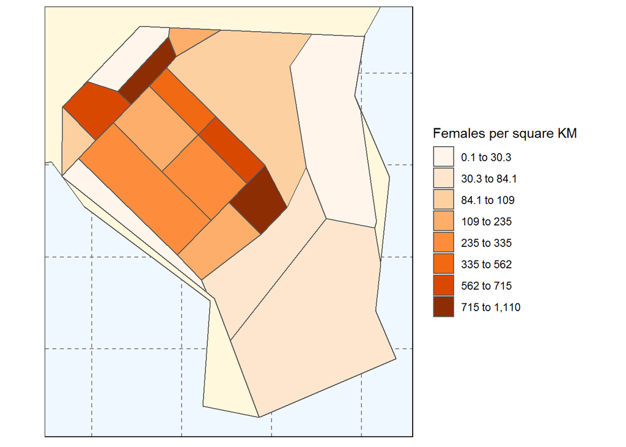

Predicted 01 July 2018 Resident Population of Female 16 to 25 Year Olds in 0800 Postal Area

Table 5: Predicted 01 July 2018 Resident Population of Male 16 to 25 Year Olds in 0800 Postal Area

| Age | Estimate | UI Low Bound (2.5%) | UI High Bound (97.5%) |
| --- | --- | --- | --- |
| 19 | 11 | 11 | 11 |
| 20 | 68 | 68 | 69 |
| 21 | 68 | 68 | 69 |
| 22 | 68 | 68 | 69 |
| 23 | 68 | 68 | 69 |
| 24 | 68 | 68 | 69 |
| 25 | 142 | 141 | 143 |

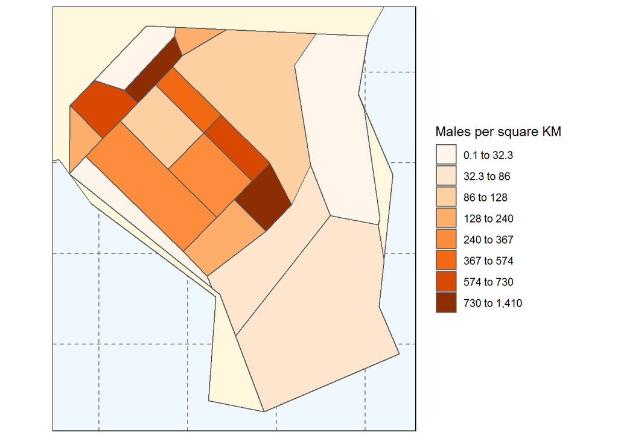

Predicted 01 July 2018 Resident Population of Male 16 to 25 Year Olds in 0800 Postal Area

Table 6: Predicted 01 July 2018 Total Resident Population of 16 to 25 Year Olds in 0800 Postal Area

| Sex | Age | Estimate | UI Low Bound (2.5%) | UI High Bound (97.5%) |
| --- | --- | --- | --- | --- |
| Female | 19-25 | 482 | 481 | 484 |
| Male | 19-25 | 495 | 493 | 497 |
| Persons | 19-25 | 978 | 975 | 979 |

[figure not shown]

Predicted 01 July 2018 Total Resident Population of 16 to 25 Year Olds in 0800 Postal Area

### 01 March 2020 Resident Population Predictions

Table 7: Predicted 01 March 2020 Resident Population of Female 16 to 25 Year Olds in 0800 Postal Area

| Age | Prediction | UI Low Bound (2.5%) | UI High Bound (97.5%) |
| --- | --- | --- | --- |
| 19 | 17 | 17 | 17 |
| 20 | 65 | 64 | 65 |
| 21 | 65 | 64 | 65 |
| 22 | 65 | 64 | 65 |
| 23 | 65 | 64 | 65 |
| 24 | 65 | 64 | 65 |
| 25 | 115 | 114 | 117 |

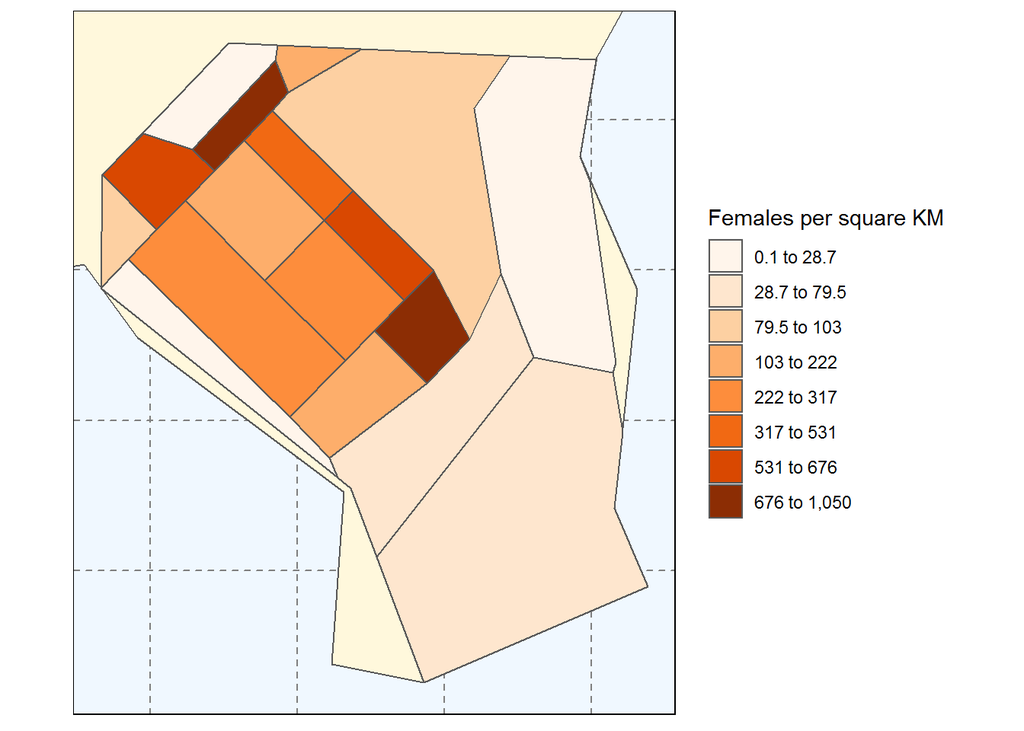

Predicted 01 March 2020 Resident Population of Female 16 to 25 Year Olds in 0800 Postal Area

Table 8: Predicted 01 March 2020 Resident Population of Male 16 to 25 Year Olds in 0800 Postal Area

| Age | Prediction | UI Low Bound (2.5%) | UI High Bound (97.5%) |
| --- | --- | --- | --- |
| 19 | 11 | 11 | 11 |
| 20 | 65 | 64 | 65 |
| 21 | 65 | 64 | 65 |
| 22 | 65 | 64 | 65 |
| 23 | 65 | 64 | 65 |
| 24 | 65 | 64 | 65 |
| 25 | 135 | 133 | 137 |

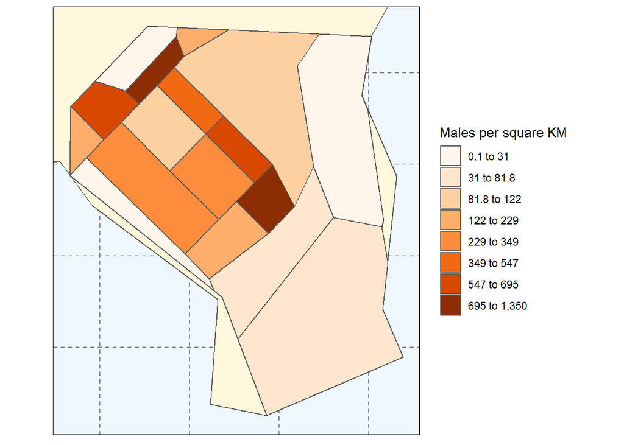

Predicted 01 March 2020 Resident Population of Male 16 to 25 Year Olds in 0800 Postal Area

Table 9: Predicted 01 March 2020 Total Resident Population of 16 to 25 Year Olds in 0800 Postal Area

| Sex | Age | Prediction | UI Low Bound (2.5%) | UI High Bound (97.5%) |
| --- | --- | --- | --- | --- |
| Female | 19-25 | 455 | 453 | 457 |
| Male | 19-25 | 471 | 467 | 475 |
| Persons | 19-25 | 927 | 922 | 929 |

[figure not shown]

Predicted 01 March 2020 Total Resident Population of 16 to 25 Year Olds in 0800 Postal Area

### Predicted Change in Resident Population Between 01 July 2018 and 01 March 2020

Table 10: Predicted Change in Resident Population of Female 16 to 25 Year Olds in 0800 Postal Area Between 01 July 2018 and 01 March 2020

| Age | Prediction | UI Low Bound (2.5%) | UI High Bound (97.5%) |
| --- | --- | --- | --- |
| 19 | -0 | -0 | -0 |
| 20 | -4 | -4 | -4 |
| 21 | -4 | -4 | -4 |
| 22 | -4 | -4 | -4 |
| 23 | -4 | -4 | -4 |
| 24 | -4 | -4 | -4 |
| 25 | -7 | -8 | -6 |

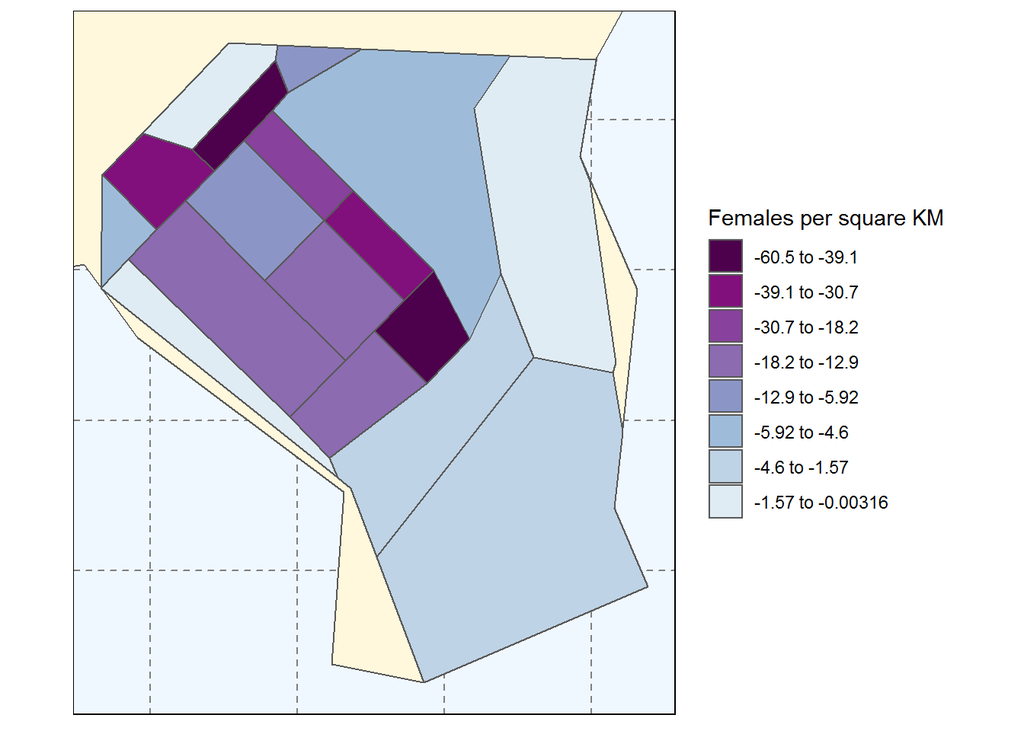

Predicted Change in Resident Population of Female 16 to 25 Year Olds in 0800 Postal Area Between 01 July 2018 and 01 March 2020

Table 11: Predicted Change in Resident Population of Male 16 to 25 Year Olds in 0800 Postal Area Between 01 July 2018 and 01 March 2020

| Age | Prediction | UI Low Bound (2.5%) | UI High Bound (97.5%) |
| --- | --- | --- | --- |
| 19 | 0 | 0 | 0 |
| 20 | -3 | -4 | -3 |
| 21 | -3 | -4 | -3 |
| 22 | -3 | -4 | -3 |
| 23 | -3 | -4 | -3 |
| 24 | -3 | -4 | -3 |
| 25 | -7 | -8 | -7 |

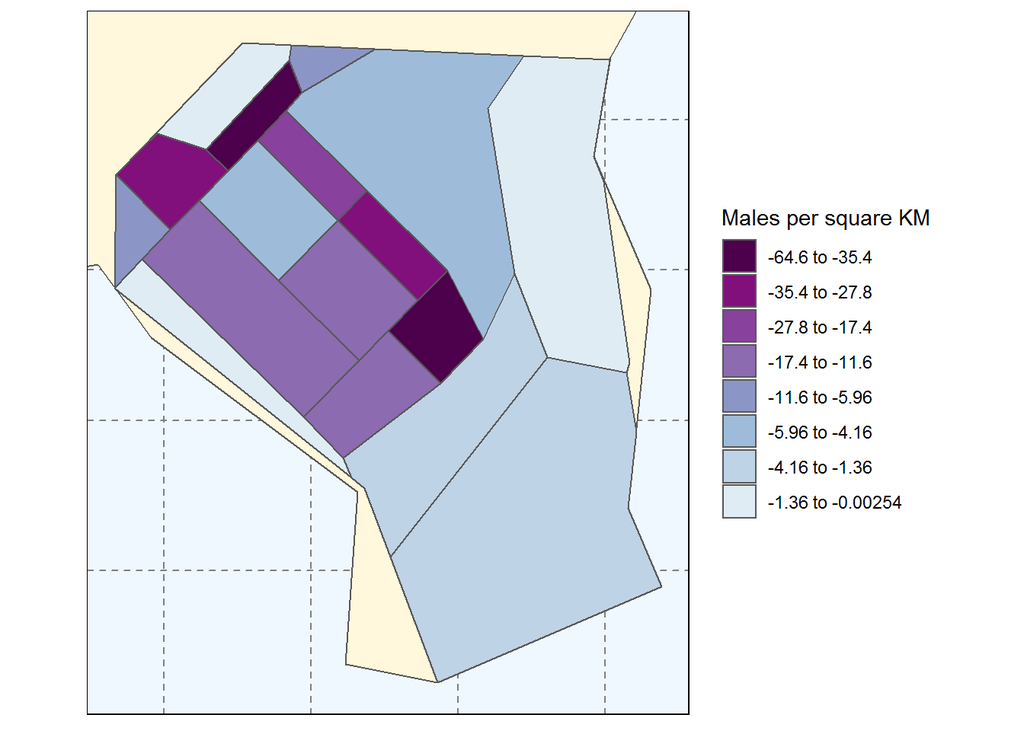

Predicted Change in Resident Population of Male 16 to 25 Year Olds in 0800 Postal Area Between 01 July 2018 and 01 March 2020

Table 12: Predicted Change in Total Resident Population of 16 to 25 Year Olds in 0800 Postal Area Between 01 July 2018 and 01 March 2020

| Sex | Age | Prediction | UI Low Bound (2.5%) | UI High Bound (97.5%) |
| --- | --- | --- | --- | --- |
| Female | 19-25 | -27 | -28 | -26 |
| Male | 19-25 | -24 | -26 | -23 |
| Persons | 19-25 | -51 | -53 | -50 |

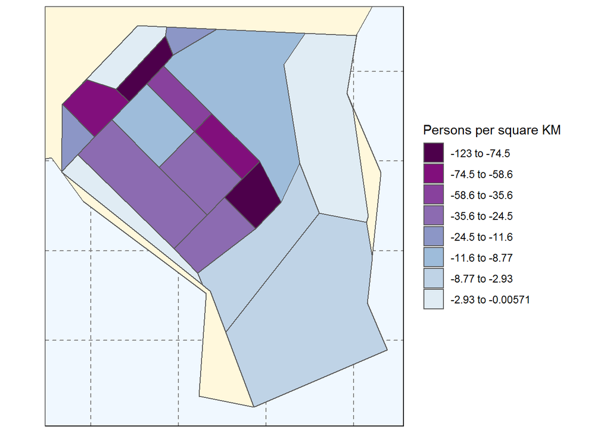

Predicted Change in Total Resident Population of 16 to 25 Year Olds in 0800 Postal Area Between 01 July 2018 and 01 March 2020

## Annual Prevalence of Any Affective Disorder Results

The predicted annual prevalence of any affective disorder amongst 16 to 25 year olds resident in 0800 Postal Area is summarised in the next nine tables and nine figures.

### 01 July 2018 Annual Prevalence of Any Affective Disorder Predictions

Table 13: Predicted 01 July 2018 Annual Prevalence of Any Affective Disorder in Female 16 to 25 Year Olds in 0800 Postal Area

| Age | Estimate | UI Low Bound (2.5%) | UI High Bound (97.5%) |
| --- | --- | --- | --- |
| 19 | 1.3 | 1.1 | 1.6 |
| 20 | 5.8 | 3.6 | 7.7 |
| 21 | 5.5 | 4.8 | 6.6 |
| 22 | 6.0 | 5.0 | 6.8 |
| 23 | 5.6 | 4.8 | 6.2 |
| 24 | 6.0 | 4.5 | 7.1 |
| 25 | 10.2 | 8.4 | 11.6 |

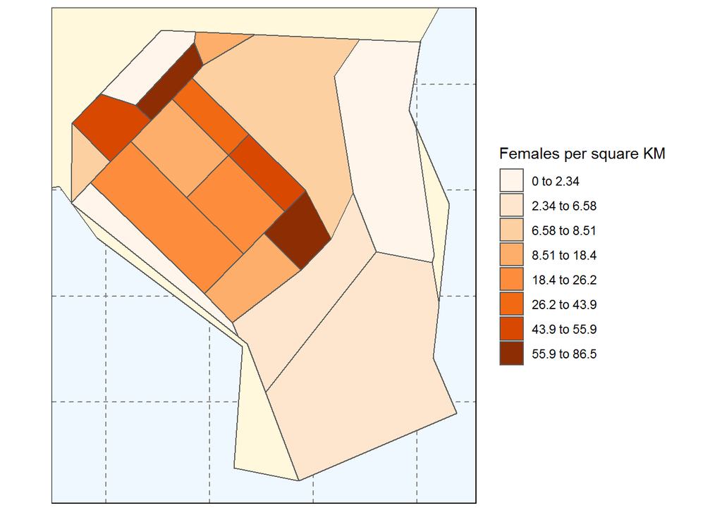

Predicted 01 July 2018 Annual Prevalence of Any Affective Disorder in Female 16 to 25 Year Olds in 0800 Postal Area

Table 14: Predicted 01 July 2018 Annual Prevalence of Any Affective Disorder in Male 16 to 25 Year Olds in 0800 Postal Area

| Age | Estimate | UI Low Bound (2.5%) | UI High Bound (97.5%) |
| --- | --- | --- | --- |
| 19 | 0.4 | 0.4 | 0.6 |
| 20 | 3.2 | 2.5 | 4.1 |
| 21 | 3.4 | 2.6 | 4.3 |
| 22 | 2.7 | 1.9 | 4.0 |
| 23 | 2.7 | 1.9 | 4.3 |
| 24 | 3.1 | 2.5 | 3.7 |
| 25 | 11.4 | 8.0 | 15.0 |

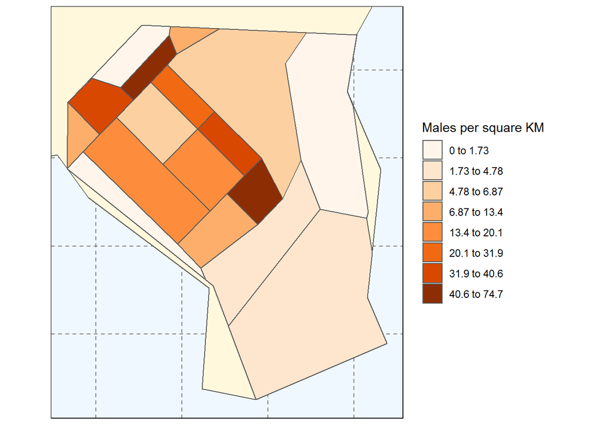

Predicted 01 July 2018 Annual Prevalence of Any Affective Disorder in Male 16 to 25 Year Olds in 0800 Postal Area

Table 15: Predicted 01 July 2018 Total Annual Prevalence of Any Affective Disorder in 16 to 25 Year Olds in 0800 Postal Area

| Sex | Age | Estimate | UI Low Bound (2.5%) | UI High Bound (97.5%) |
| --- | --- | --- | --- | --- |
| Female | 19-25 | 40.0 | 37.1 | 43.2 |
| Male | 19-25 | 27.6 | 23.8 | 31.0 |
| Persons | 19-25 | 66.5 | 63.3 | 74.0 |

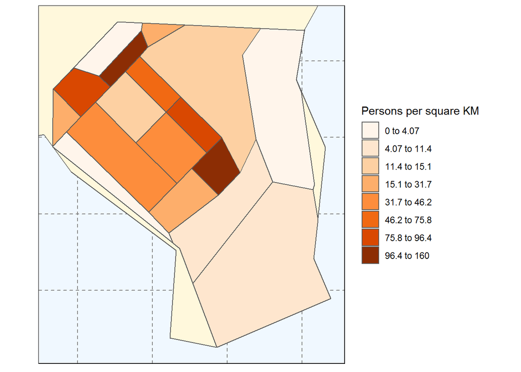

Predicted 01 July 2018 Total Annual Prevalence of Any Affective Disorder in 16 to 25 Year Olds in 0800 Postal Area

### 01 March 2020 Annual Prevalence of Any Affective Disorder Predictions

Table 16: Predicted 01 March 2020 Annual Prevalence of Any Affective Disorder in Female 16 to 25 Year Olds in 0800 Postal Area

| Age | Prediction | UI Low Bound (2.5%) | UI High Bound (97.5%) |
| --- | --- | --- | --- |
| 19 | 1.3 | 1.1 | 1.6 |
| 20 | 5.5 | 3.3 | 7.3 |
| 21 | 5.1 | 4.5 | 6.2 |
| 22 | 5.6 | 4.7 | 6.4 |
| 23 | 5.3 | 4.5 | 5.9 |
| 24 | 5.7 | 4.3 | 6.6 |
| 25 | 9.6 | 7.9 | 10.9 |

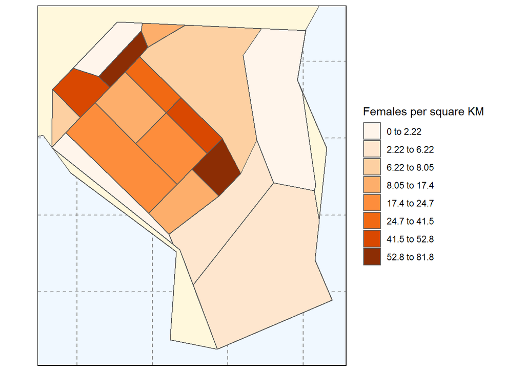

Predicted 01 March 2020 Annual Prevalence of Any Affective Disorder in Female 16 to 25 Year Olds in 0800 Postal Area

Table 17: Predicted 01 March 2020 Annual Prevalence of Any Affective Disorder in Male 16 to 25 Year Olds in 0800 Postal Area

| Age | Prediction | UI Low Bound (2.5%) | UI High Bound (97.5%) |
| --- | --- | --- | --- |
| 19 | 0.5 | 0.4 | 0.6 |
| 20 | 3.0 | 2.3 | 3.9 |
| 21 | 3.2 | 2.5 | 4.1 |
| 22 | 2.5 | 1.8 | 3.8 |
| 23 | 2.5 | 1.8 | 4.1 |
| 24 | 2.9 | 2.4 | 3.5 |
| 25 | 10.8 | 7.6 | 14.3 |

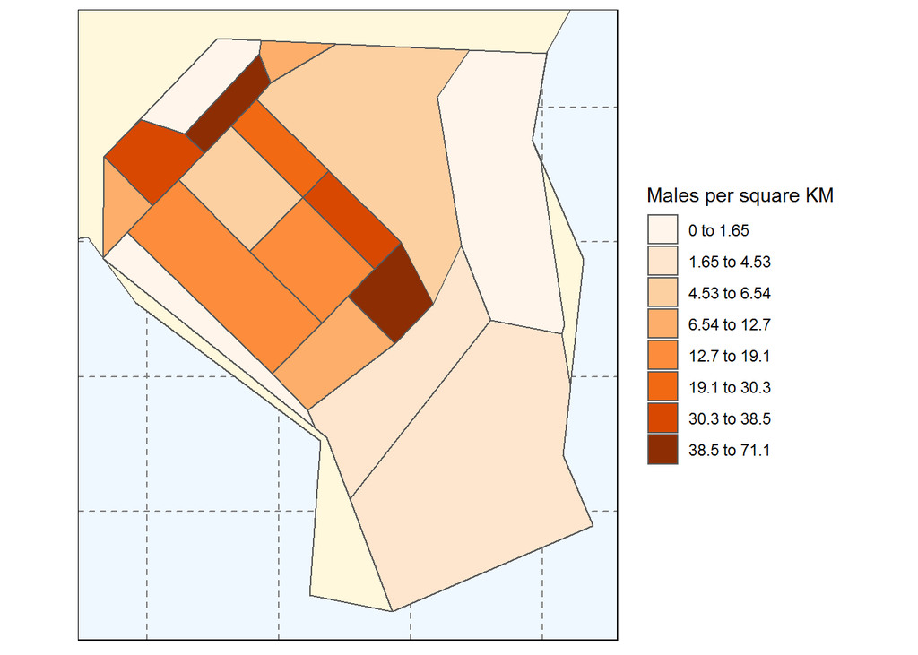

Predicted 01 March 2020 Annual Prevalence of Any Affective Disorder in Male 16 to 25 Year Olds in 0800 Postal Area

Table 18: Predicted 01 March 2020 Total Annual Prevalence of Any Affective Disorder in 16 to 25 Year Olds in 0800 Postal Area

| Sex | Age | Prediction | UI Low Bound (2.5%) | UI High Bound (97.5%) |
| --- | --- | --- | --- | --- |
| Female | 19-25 | 37.8 | 35.0 | 40.7 |
| Male | 19-25 | 26.2 | 22.7 | 29.5 |
| Persons | 19-25 | 62.9 | 59.9 | 70.0 |

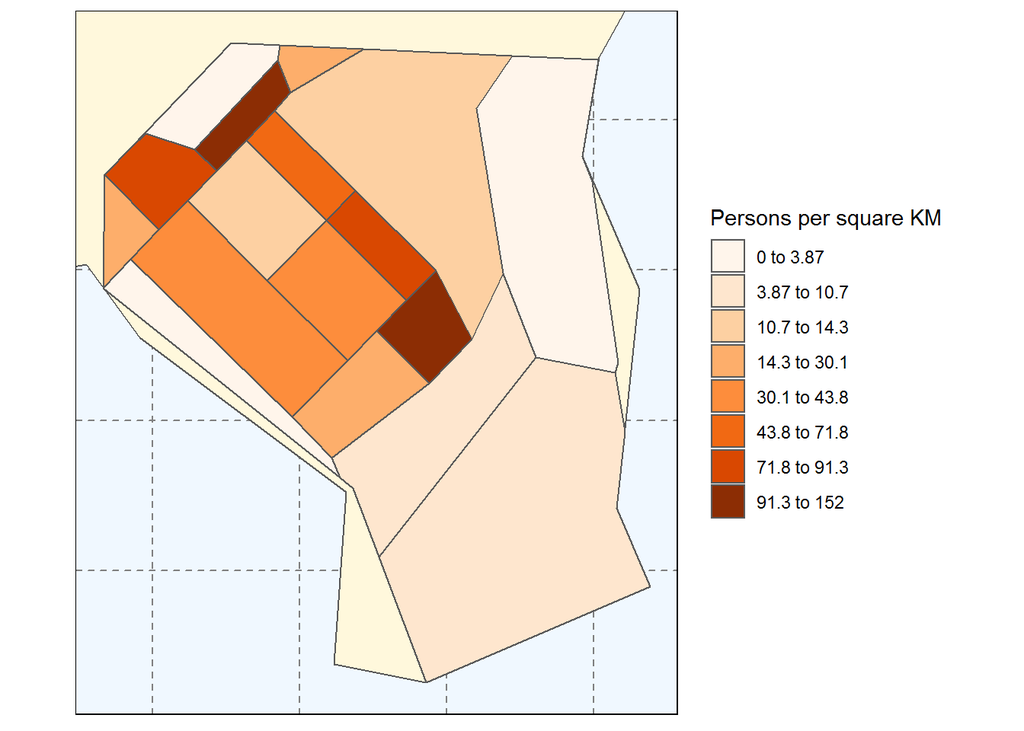

Predicted 01 March 2020 Total Annual Prevalence of Any Affective Disorder in 16 to 25 Year Olds in 0800 Postal Area

### Predicted Change in Annual Prevalence of Any Affective Disorder Between 01 July 2018 and 01 March 2020

Table 19: Predicted Change in Annual Prevalence of Any Affective Disorder in Female 16 to 25 Year Olds in 0800 Postal Area Between 01 July 2018 and 01 March 2020

| Age | Prediction | UI Low Bound (2.5%) | UI High Bound (97.5%) |
| --- | --- | --- | --- |
| 19 | -0.0 | -0.0 | -0.0 |
| 20 | -0.4 | -0.5 | -0.2 |
| 21 | -0.3 | -0.4 | -0.3 |
| 22 | -0.3 | -0.4 | -0.3 |
| 23 | -0.3 | -0.4 | -0.3 |
| 24 | -0.4 | -0.4 | -0.3 |
| 25 | -0.6 | -0.7 | -0.5 |

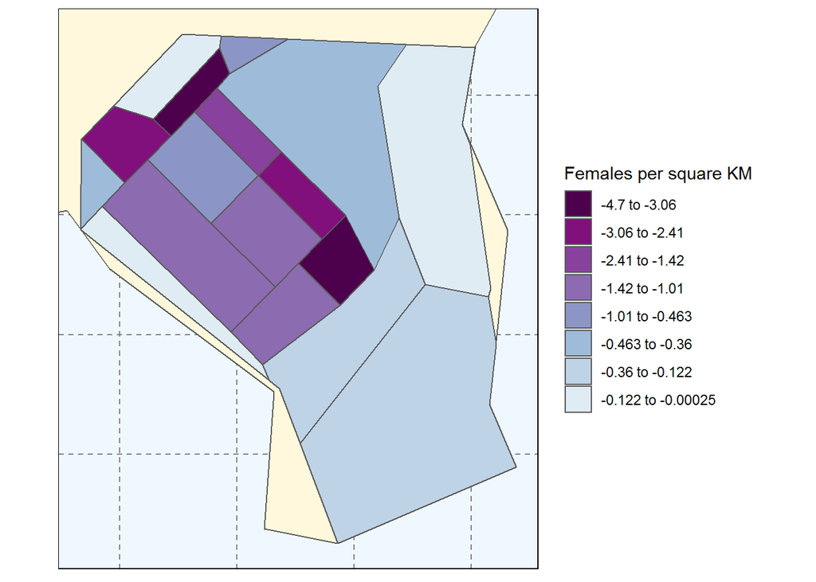

Predicted Change in Annual Prevalence of Any Affective Disorder in Female 16 to 25 Year Olds in 0800 Postal Area Between 01 July 2018 and 01 March 2020

Table 20: Predicted Change in Annual Prevalence of Any Affective Disorder in Male 16 to 25 Year Olds in 0800 Postal Area Between 01 July 2018 and 01 March 2020

| Age | Prediction | UI Low Bound (2.5%) | UI High Bound (97.5%) |
| --- | --- | --- | --- |
| 19 | 0.0 | 0.0 | 0.0 |
| 20 | -0.2 | -0.2 | -0.1 |
| 21 | -0.2 | -0.2 | -0.1 |
| 22 | -0.1 | -0.2 | -0.1 |
| 23 | -0.1 | -0.2 | -0.1 |
| 24 | -0.2 | -0.2 | -0.1 |
| 25 | -0.6 | -0.7 | -0.4 |

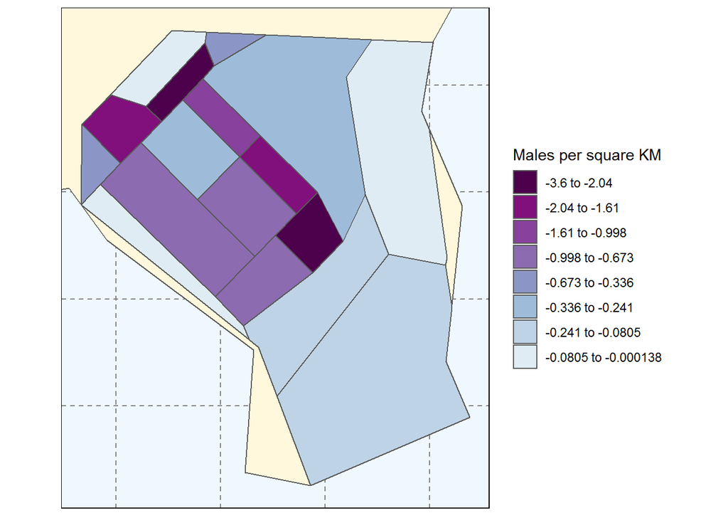

Predicted Change in Annual Prevalence of Any Affective Disorder in Male 16 to 25 Year Olds in 0800 Postal Area Between 01 July 2018 and 01 March 2020

Table 21: Predicted Change in Total Annual Prevalence of Any Affective Disorder in 16 to 25 Year Olds in 0800 Postal Area Between 01 July 2018 and 01 March 2020

| Sex | Age | Prediction | UI Low Bound (2.5%) | UI High Bound (97.5%) |
| --- | --- | --- | --- | --- |
| Female | 19-25 | -2.3 | -2.5 | -2.1 |
| Male | 19-25 | -1.4 | -1.6 | -1.1 |
| Persons | 19-25 | -3.6 | -4.1 | -3.4 |

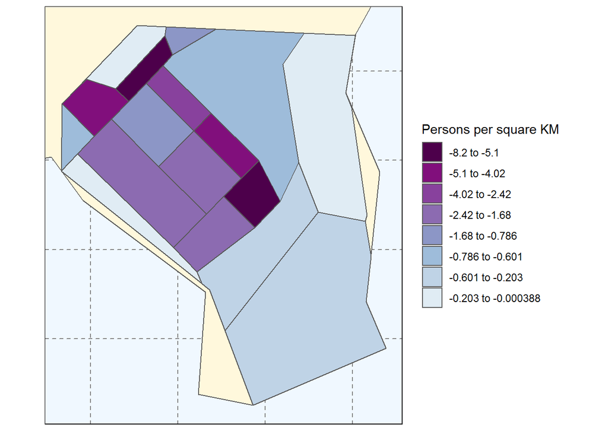

Predicted Change in Total Annual Prevalence of Any Affective Disorder in 16 to 25 Year Olds in 0800 Postal Area Between 01 July 2018 and 01 March 2020

# Discussion

The results presented in this report are produced by an algorithm that synthesises Australian geometry and spatial attribute data. Strengths of this automated approach include the relevance of the input data to the Australian context and using data at the highest available spatial resolution. However, there are also a number of limitations that users of this report should bear in mind when interpreting report results.

First and most importantly, this report is produced by a development version of the Springtides App, which means both the application and its underlying model are only partially verified and validated. An updated version of the Springtides App will be released once user testing, code and input data verification and validation checks have been completed. Secondly, uncertainty is only partially explored and the true uncertainty of model outputs will be greater than that described in this report. Some model inputs currently only have deterministic values, structural uncertainty is not yet explored and to conserve computing resources we have restricted Springtides App users to running a maximum of 100 iterations of each simulation. We will be shortly addressing each of these constraints in a forthcoming development release as well as providing opportunities to explore structural uncertainty through selection of alternative evidence sources for a number of model parameters. Thirdly, epidemiology estimates are currently based on age and sex predictors only. Area attributes such as urbanicity and socioeconomic status will be added to the predictors in a forthcoming development version release.

# Contact

You can help improve the Springtides App by reporting any suspected errors or providing usability feedback to the Springtides development team. Email: matthew.hamilton@orygen.org.au